# MDPs with external processes

Lars Relund lars@relund.dk

2015-11-05

In this vignette we give a few examples on how to generate a MDP with external processes. An external process is a finite horizon MDP which is added to a HMDP as a child process. This can be done multiple times such that the HMDP can have multiple external processes. External processes are added using the `includeProcess` function in the `binaryMDPWriter` and stored in the HMDP by specifying the jump actions of the external process. That is, the HMDP store the first and last stage of the external process and its corresponding jump actions.

Building a HMDP with external processes is beneficial when the model is so large that it can not be loaded into memory, since the external processes is loaded and unloaded from memory only when needed in e.g. calculations of the optimal policy. I may also be of use if the same external process is used many times in the HMDP (with different jump actions).

# Example using R

In this vignette we give an example of a small HMDP with external processes. First we generate the full HMDP without external processes.

```r
# function for creating subprocess proc1
Proc1<-function(jumpActions=TRUE) {
   w$process()
      w$stage()   # stage n=0
         w$state(label="good")
            w$action(label="mt", weights=c(55,1), prob=c(1,0,1), end=TRUE)
            w$action(label="nmt", weights=c(70,1), prob=c(1,0,0.6, 1,1,0.4), end=TRUE)
         w$endState()
         w$state(label="average")
            w$action(label="mt", weights=c(40,1), prob=c(1,0,1), end=TRUE)
            w$action(label="nmt", weights=c(50,1), prob=c(1,1,0.6, 1,2,0.4), end=TRUE)
         w$endState()
      w$endStage()
      w$stage()   # stage n=1
         w$state(label="good")
            if (jumpActions) w$action(label="rep", weights=c(30,1), prob=c(0,0,1), end=TRUE)
         w$endState()
         w$state(label="average")
            if (jumpActions) w$action(label="rep", weights=c(10,1), prob=c(0,0,1), end=TRUE)
         w$endState()
         w$state(label="not working")
            if (jumpActions) w$action(label="rep", weights=c(5,1), prob=c(0,0,1), end=TRUE)
         w$endState()
      w$endStage()
   w$endProcess()
}


# function for creating subprocess proc2
Proc2<-function(jumpActions=TRUE) {
   w$process()
      w$stage()   # stage n=0
         w$state(label="Dummy")
            w$action(label="buy", weights=c(-100,1), prob=c(1,0,0.7, 1,1,0.3), end=TRUE)
         w$endState()
      w$endStage()
      w$stage()   # stage n=1
         w$state(label="good")
            w$action(label="mt", weights=c(55,1), prob=c(1,0,1), end=TRUE)
            w$action(label="nmt", weights=c(70,1), prob=c(1,0,0.6, 1,1,0.4), end=TRUE)
         w$endState()
         w$state(label="average")
            w$action(label="mt", weights=c(40,1), prob=c(1,0,1), end=TRUE)
            w$action(label="nmt", weights=c(50,1), prob=c(1,1,0.6, 1,2,0.4), end=TRUE)
         w$endState()
      w$endStage()
      w$stage()   # stage n=2
         w$state(label="good")
            w$action(label="mt", weights=c(55,1), prob=c(1,0,1), end=TRUE)
            w$action(label="nmt", weights=c(70,1), prob=c(1,0,0.5, 1,1,0.5), end=TRUE)
         w$endState()
         w$state(label="average")
            w$action(label="mt", weights=c(40,1), prob=c(1,0,1), end=TRUE)
            w$action(label="nmt", weights=c(50,1), prob=c(1,1,0.5, 1,2,0.5), end=TRUE)
         w$endState()
         w$state(label="not working")
            w$action(label="mt", weights=c(30,1), prob=c(1,0,1), end=TRUE)
            w$action(label="rep", weights=c(5,1), prob=c(1,2,1), end=TRUE)
         w$endState()
      w$endStage()
      w$stage()   # stage n=3
         w$state(label="good")
            w$action(label="mt", weights=c(55,1), prob=c(1,0,1), end=TRUE)
            w$action(label="nmt", weights=c(70,1), prob=c(1,0,0.2, 1,1,0.8), end=TRUE)
         w$endState()
         w$state(label="average")
            w$action(label="mt", weights=c(40,1), prob=c(1,0,1), end=TRUE)
            w$action(label="nmt", weights=c(50,1), prob=c(1,1,0.2, 1,2,0.8), end=TRUE)
         w$endState()
         w$state(label="not working")
            w$action(label="mt", weights=c(30,1), prob=c(1,0,1), end=TRUE)
            w$action(label="rep", weights=c(5,1), prob=c(1,1,1), end=TRUE)
         w$endState()
      w$endStage()
      w$stage()   # stage n=4
         w$state(label="good")
            if (jumpActions) w$action(label="rep", weights=c(30,1), prob=c(0,1,1), end=TRUE)
         w$endState()
         w$state(label="average")
            if (jumpActions) w$action(label="rep", weights=c(10,1), prob=c(0,1,1), end=TRUE)
         w$endState()
         w$state(label="not working")
            if (jumpActions) w$action(label="rep", weights=c(5,1), prob=c(0,1,1), end=TRUE)
         w$endState()
      w$endStage()
   w$endProcess()
}

# build the HMDP (without external processes)
prefix<-"hmdp_"
w<-binaryMDPWriter(prefix)
w$setWeights(c("Reward","Time"))
w$process() # founder process with a single state
   w$stage()
      w$state(label="M0")
         w$action(label="A0",weights=c(0,1),prob=c(2,0,1))
            w$process() # level 1 process with 3 stages
               w$stage() # 1. stage with one state
                  w$state(label="D")
                     w$action(label="A0",weights=c(0,1),prob=c(1,0,0.5,1,1,0.5), end=T)
                     w$action(label="A1",weights=c(0,1),prob=c(2,0,0.5,2,1,0.5))
                        Proc1()
                     w$endAction()
                  w$endState()
               w$endStage()
               w$stage()
                  w$state(label="C0")
                     w$action(label="A0",weights=c(0,0),prob=c(2,0,1))
                        Proc1()
                     w$endAction()
                  w$endState()
                  w$state(label="C1")
                     w$action(label="A0",weights=c(0,1),prob=c(2,0,1))
                        Proc2()
                     w$endAction()
                  w$endState()
               w$endStage()
               w$stage()
                  w$state(label="C0")
                     w$action(label="A0",weights=c(4,1),prob=c(0,0,1))
                     w$endAction()
                  w$endState()
                  w$state(label="C1")
                     w$action(label="A0",weights=c(1,1),prob=c(0,0,1))
                     w$endAction()
                  w$endState()
               w$endStage()
            w$endProcess()
         w$endAction()
      w$endState()
   w$endStage()
w$endProcess()
w$closeWriter()
```

```
##
##   Statistics:
##     states : 28
##     actions: 41
##     weights: 2
##
##   Closing binary MDP writer.
```

A plot of the HMDP:

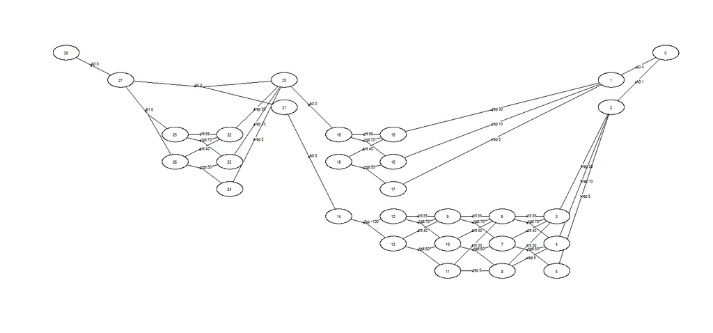

Note that process 1 is used two places (with different jump actions) and process 2 one place. Now let us generate the HMDP with external processes. First we build the external processes.

```r
w<-binaryMDPWriter("proc1_")
w$setWeights(c("Reward","Time"))
Proc1(jumpActions = F)
w$closeWriter()
```

```
##
##   Statistics:
##     states : 5
##     actions: 4
##     weights: 2
##
##   Closing binary MDP writer.
```

```r
w<-binaryMDPWriter("proc2_")
w$setWeights(c("Reward","Time"))
Proc2(jumpActions = F)
w$closeWriter()
```

```
##
##   Statistics:
##     states : 12
##     actions: 17
##     weights: 2
##
##   Closing binary MDP writer.
```

A plot of process 1:

```
## Read binary files (0.0126522 sec.)
## Build the HMDP (5.0607e-005 sec.)
##
## Checking MDP and found no errors (1.416e-006 sec.)
```

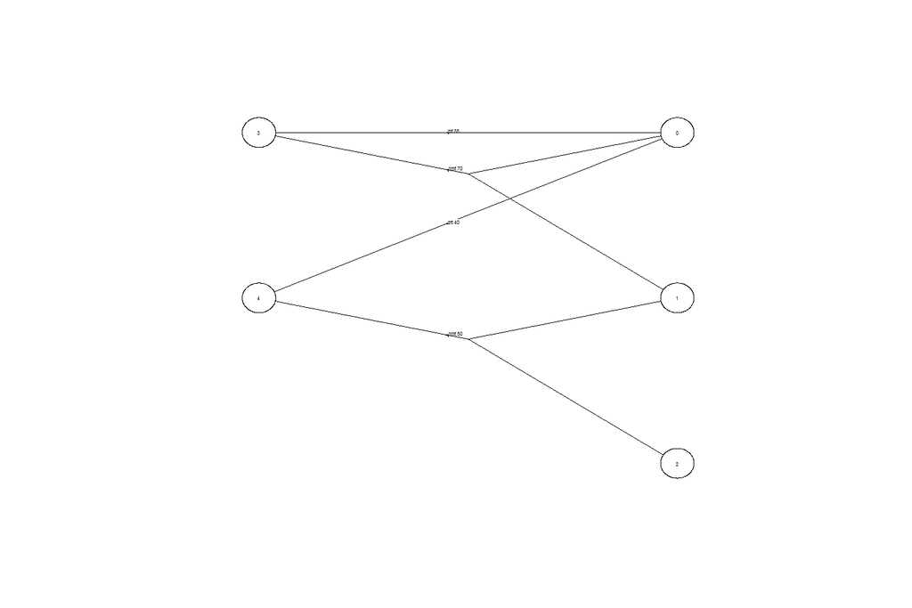

A plot of process 2:

```
## Read binary files (0.0129866 sec.)
## Build the HMDP (9.5906e-005 sec.)
##
## Checking MDP and found no errors (1.769e-006 sec.)
```

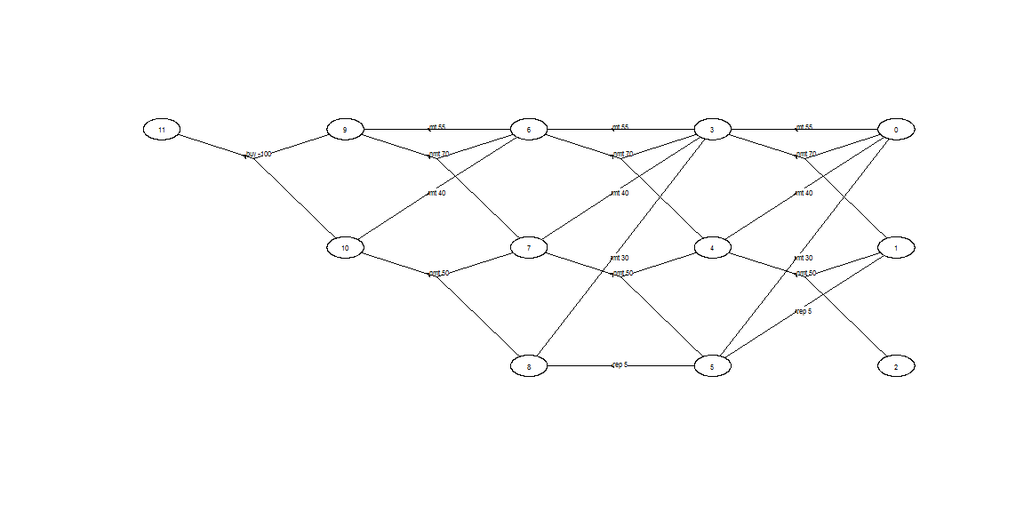

Next step is to generate the HMDP with external processes:

```r
# build the HMDP (without external processes)
prefix<-"ext_"
w<-binaryMDPWriter(prefix)
w$setWeights(c("Reward","Time"))
w$process() # founder process with a single state
   w$stage()
      w$state(label="M0")
         w$action(label="A0",weights=c(0,1),prob=c(2,0,1))
            w$process() # level 1 process with 3 stages
               w$stage() # 1. stage with one state
                  w$state(label="D")
                     w$action(label="A0",weights=c(0,1),prob=c(1,0,0.5,1,1,0.5), end=T)
                        w$includeProcess(prefix="proc1_", label="A1", weights=c(0,1),prob=c(2,0,0.5,2,1,0.5), termStates=3)
                           w$stage()   # last stage in in external process
                              w$state(label="good")
                                 w$action(label="rep", weights=c(30,1), prob=c(0,0,1), end=TRUE)
                              w$endState()
                              w$state(label="average")
                                 w$action(label="rep", weights=c(10,1), prob=c(0,0,1), end=TRUE)
                              w$endState()
                              w$state(label="not working")
                                 w$action(label="rep", weights=c(5,1), prob=c(0,0,1), end=TRUE)
                              w$endState()
                           w$endStage()
                        w$endIncludeProcess()
                  w$endState()
               w$endStage()
               w$stage()
                  w$state(label="C0")
                     w$includeProcess(prefix="proc1_", label="A0",weights=c(0,0),prob=c(2,0,1), termStates=3)
                        w$stage()   # last stage in in external process
                           w$state(label="good")
                              w$action(label="rep", weights=c(30,1), prob=c(0,0,1), end=TRUE)
                           w$endState()
                           w$state(label="average")
                              w$action(label="rep", weights=c(10,1), prob=c(0,0,1), end=TRUE)
                           w$endState()
                           w$state(label="not working")
                              w$action(label="rep", weights=c(5,1), prob=c(0,0,1), end=TRUE)
                           w$endState()
                        w$endStage()
                     w$endIncludeProcess()
                  w$endState()
                  w$state(label="C1")
                     w$includeProcess(prefix="proc2_", label="A0",weights=c(0,1),prob=c(2,0,1), termStates=3)
                        w$stage()   # last stage in in external process
                           w$state(label="good")
                              w$action(label="rep", weights=c(30,1), prob=c(0,1,1), end=TRUE)
                           w$endState()
                           w$state(label="average")
                              w$action(label="rep", weights=c(10,1), prob=c(0,1,1), end=TRUE)
                           w$endState()
                           w$state(label="not working")
                              w$action(label="rep", weights=c(5,1), prob=c(0,1,1), end=TRUE)
                           w$endState()
                        w$endStage()
                     w$endIncludeProcess()
                  w$endState()
               w$endStage()
               w$stage()
                  w$state(label="C0")
                     w$action(label="A0",weights=c(4,1),prob=c(0,0,1))
                     w$endAction()
                  w$endState()
                  w$state(label="C1")
                     w$action(label="A0",weights=c(1,1),prob=c(0,0,1))
                     w$endAction()
                  w$endState()
               w$endStage()
            w$endProcess()
         w$endAction()
      w$endState()
   w$endStage()
w$endProcess()
w$closeWriter()
```

```
##
##   Statistics:
##     states : 19
##     actions: 20
##     weights: 2
##
##   Closing binary MDP writer.
```

Note the new syntax `includeProcess` which must contain the prefix of the external process and the jump action to the first stage of the external process. Furthermore, the number of states at the last stage of the external process must also be specified. Finally inside the `includeProcess` the last stage of the external process must be included (which must be equal to the process you link to), so that the jump actions back to the father is specified.

Let us have a look at the binary file `ext_externalProcesses.bin` used to indicate that we consider a HMDP with external processes:

```r
fileN<-"ext_externalProcesses.bin"
readBin(fileN, character(),n=file.info(fileN)$size)
```

```
## [1] "0,0,0,0,0,1,0" "proc1_"        "0,0,0,1,0,0,0" "proc1_"        "0,0,0,1,1,0,0" "proc2_"
```

As can be seen each pair specify which stage corresponds to the first stage in the external process and next the prefix of the external process.

Let us have a look at a plot of the HMDP with external processes:

```
## Read binary files (0.0172917 sec.)
## Start building the HMDP ...
##   Create map for stages (0.000139082 sec.)
##   Transform actions to internal data structure (0.000244189 sec.)
##   Find valid ordering of stages (0.000137311 sec.)
##   Build the internal HMDP data structure (3.5389e-005 sec.)
##   Sort transitions increasing in state id (1.416e-006 sec.)
## Build the HMDP (0.000579683 sec.)
##
## Checking MDP and found no errors (3.185e-006 sec.)
```

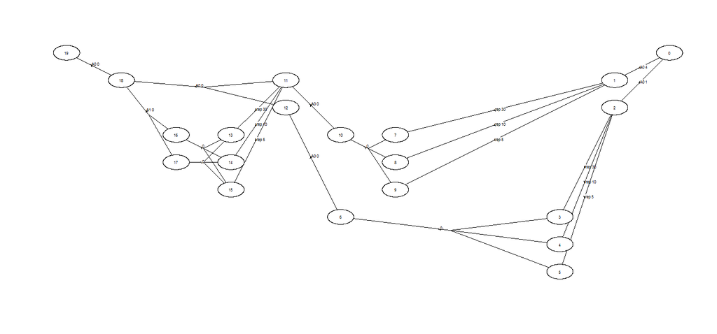

Note that the states in the first stage of the external process which have a transition from the father is automatically defined. That is, the HMDP with external processes contain first and last stage of the external processes and dummy actions from the first stage to the last stage. Moreover, the states corresponding to the first stage of an external process is automatically given the label corresponding to the stage index:

```r
infoMDP(mdpExt, stageStr = mdpExt$external$stageStr)$stateDF
```

```
##   sId        stateStr         label
## 1  16 0,0,0,0,0,1,0,0 0,0,0,0,0,1,0
## 2  17 0,0,0,0,0,1,0,1 0,0,0,0,0,1,0
## 3  10 0,0,0,1,0,0,0,0 0,0,0,1,0,0,0
## 4   6 0,0,0,1,1,0,0,0 0,0,0,1,1,0,0
```

Let us try to experiment using policy iteration. We solve useing the full HMDP and the HMDP with external processes:

```r
gFull<-policyIteAve(mdpFull, "Reward", "Time")
```

```
## Run policy iteration under average reward criterion using
## reward 'Reward' over 'Time'. Iterations (g):
## 1 (12.8929) 2 (25.2857) 3 (25.2857) finished. Cpu time: 2.831e-006 sec.
```

```r
gExt<-policyIteAve(mdpExt, "Reward", "Time")
```

```
## Run policy iteration under average reward criterion using
## reward 'Reward' over 'Time'. Iterations (g):
##   Allocate memory for external process with prefix 'proc2_'.
##   Free memory of external process with prefix 'proc2_'.
##   Allocate memory for external process with prefix 'proc1_'.
##   Use current external process with prefix 'proc1_' again.
##   Free memory of external process with prefix 'proc1_'.
##
## 1
## (25.2857)
##   Allocate memory for external process with prefix 'proc2_'.
##   Free memory of external process with prefix 'proc2_'.
##   Allocate memory for external process with prefix 'proc1_'.
##   Use current external process with prefix 'proc1_' again.
##   Free memory of external process with prefix 'proc1_'.
## 2 (25.2857)
## finished. Cpu time: 3.185e-006 sec.
```

```r
gFull == gExt
```

```
## [1] TRUE
```

Note that memory of the external processes is allocated and deallocated when needed. Indeed since process 1 is used two times in a row a reallocation is not done. If we compare the policies we get:

```r
idx <- data.frame(full=c(0:5,14:18,20:28), ext=0:19)
polFull<-getPolicy(mdpFull,sId = idx$full)
polExt<-getPolicy(mdpExt, sId = idx$ext)
polFull
```

```
##    sId  stateLabel aIdx actionLabel        weight
## 1    0               -1              0.000000e+00
## 2    1          C0    0          A0 -2.128571e+01
## 3    2          C1    0          A0 -2.428571e+01
## 4    3        good    0         rep -1.957143e+01
## 5    4     average    0         rep -3.957143e+01
## 6    5 not working    0         rep -4.457143e+01
## 7   14       Dummy    0         buy -4.851429e+01
## 8   15        good    0         rep -1.657143e+01
## 9   16     average    0         rep -3.657143e+01
## 10  17 not working    0         rep -4.157143e+01
## 11  18        good    1         nmt  2.014286e+01
## 12  20          C0    0          A0  2.014286e+01
## 13  21          C1    0          A0 -7.380000e+01
## 14  22        good    0         rep  2.485714e+01
## 15  23     average    0         rep  4.857143e+00
## 16  24 not working    0         rep -1.428571e-01
## 17  25        good    1         nmt  6.157143e+01
## 18  26     average    0          mt  3.957143e+01
## 19  27           D    1          A1  2.528571e+01
## 20  28          M0    0          A0  7.105427e-15
```

```r
polFull$weight == polExt$weight
```

```
##  [1] TRUE TRUE TRUE TRUE TRUE TRUE TRUE TRUE TRUE TRUE TRUE TRUE TRUE TRUE TRUE TRUE TRUE TRUE TRUE
## [20] TRUE
```

Note here we only get the optimal policy of the loaded HMDP when consider external processes. However, if we want to get the optimal policy of the external processes we can do that by loading the processes and assigning rewards of the last stage as the terminal rewards:

```r
# process 1 optimal policy - external at stage "0,0,0,0,0,1,0"
lastStage<-"0,0,0,0,0,1,1"
termValues <- getPolicy(mdpExt, stageStr = lastStage)$weight
valueIte(mdp1, 'Reward', 'Time', termValues=termValues, g=gExt)
```

```
## Run value iteration with epsilon = 1e-005 at most 1 time(s)
## using quantity 'Reward' under average reward criterion given an average reward g = 25.2857.
##  Finished. Cpu time 1.1325e-005 sec.
```

```r
polFull<-getPolicy(mdpFull,sId = 22:26)
polExt<-getPolicy(mdp1)
cbind(polFull,polExt)
```

```
##   sId  stateLabel aIdx actionLabel     weight sId  stateLabel aIdx actionLabel     weight
## 1  22        good    0         rep 24.8571429   0        good   -1             24.8571429
## 2  23     average    0         rep  4.8571429   1     average   -1              4.8571429
## 3  24 not working    0         rep -0.1428571   2 not working   -1             -0.1428571
## 4  25        good    1         nmt 61.5714286   3        good    1         nmt 61.5714286
## 5  26     average    0          mt 39.5714286   4     average    0          mt 39.5714286
```

```r
# process 1 optimal policy - external at stage "0,0,0,1,0,0,0"
lastStage<-"0,0,0,1,0,0,1"
termValues <- getPolicy(mdpExt, stageStr = lastStage)$weight
valueIte(mdp1, 'Reward', 'Time', termValues=termValues, g=gExt)
```

```
## Run value iteration with epsilon = 1e-005 at most 1 time(s)
## using quantity 'Reward' under average reward criterion given an average reward g = 25.2857.
##  Finished. Cpu time 1.2033e-005 sec.
```

```r
polFull<-getPolicy(mdpFull,sId = 15:18)
polExt<-getPolicy(mdp1, sId=0:3)
cbind(polFull,polExt)
```

```
##   sId  stateLabel aIdx actionLabel    weight sId  stateLabel aIdx actionLabel    weight
## 1  15        good    0         rep -16.57143   0        good   -1             -16.57143
## 2  16     average    0         rep -36.57143   1     average   -1             -36.57143
## 3  17 not working    0         rep -41.57143   2 not working   -1             -41.57143
## 4  18        good    1         nmt  20.14286   3        good    1         nmt  20.14286
```

```r
# process 2 optimal policy - external at stage "0,0,0,1,1,0,0"
lastStage<-"0,0,0,1,1,0,1"
termValues <- getPolicy(mdpExt, stageStr = lastStage)$weight
valueIte(mdp2, 'Reward', 'Time', termValues=termValues, g=gExt)
```

```
## Run value iteration with epsilon = 1e-005 at most 1 time(s)
## using quantity 'Reward' under average reward criterion given an average reward g = 25.2857.
##  Finished. Cpu time 1.2033e-005 sec.
```

```r
polFull<-getPolicy(mdpFull,sId = 3:14)
polExt<-getPolicy(mdp2)
cbind(polFull,polExt)
```

```
##    sId  stateLabel aIdx actionLabel     weight sId  stateLabel aIdx actionLabel     weight
## 1    3        good    0         rep -19.571429   0        good   -1             -19.571429
## 2    4     average    0         rep -39.571429   1     average   -1             -39.571429
## 3    5 not working    0         rep -44.571429   2 not working   -1             -44.571429
## 4    6        good    0          mt  10.142857   3        good    0          mt  10.142857
## 5    7     average    0          mt  -4.857143   4     average    0          mt  -4.857143
## 6    8 not working    0          mt -14.857143   5 not working    0          mt -14.857143
## 7    9        good    1         nmt  47.357143   6        good    1         nmt  47.357143
## 8   10     average    0          mt  24.857143   7     average    0          mt  24.857143
## 9   11 not working    0          mt  14.857143   8 not working    0          mt  14.857143
## 10  12        good    1         nmt  83.071429   9        good    1         nmt  83.071429
## 11  13     average    0          mt  62.071429  10     average    0          mt  62.071429
## 12  14       Dummy    0         buy -48.514286  11       Dummy    0         buy -48.514286
```

In fact we can use `getPolicy` directly to get the above results

```r
getPolicy(mdpExt, external = mdpExt$external$stageStr, w = 'Reward', dur = 'Time', g = gExt)
```

```
## $main
##    sId    stateLabel aIdx actionLabel        weight
## 1    1            C0    0          A0 -2.128571e+01
## 2    2            C1    0          A0 -2.428571e+01
## 3    3          good    0         rep -1.957143e+01
## 4    4       average    0         rep -3.957143e+01
## 5    5   not working    0         rep -4.457143e+01
## 6    6 0,0,0,1,1,0,0    0             -4.851429e+01
## 7    7          good    0         rep -1.657143e+01
## 8    8       average    0         rep -3.657143e+01
## 9    9   not working    0         rep -4.157143e+01
## 10  10 0,0,0,1,0,0,0    0              2.014286e+01
## 11  11            C0    0          A0  2.014286e+01
## 12  12            C1    0          A0 -7.380000e+01
## 13  13          good    0         rep  2.485714e+01
```

[output cut: 37 more lines]

Note you have to add arguments to `getPolicy` needed when `valueIte` is called.

# Examples using C++

We test external processes using the binaryMDPWriter on the C++ side. We link to code defined in the `MDP2` package using `Rcpp::depends` attribute. Let us try to build a simple HMDP with one external process:

```cpp
// [[Rcpp::depends(MDP2)]]
#include <Rcpp.h>
#include <binaryMDPWriter.h>
using namespace Rcpp;

template <typename T>
vector<T> vA(vector<T> & v, T val) {
   v.assign(1,val);
   return v;
}

template <typename T>
vector<T> vA(vector<T> & v, T val1, T val2) {
   v.clear();
   v.push_back(val1);
   v.push_back(val2);
   return v;
}

// [[Rcpp::export]]
void buildHMDP() {
vector<int> idx, scp;
vector<double> pr,w;
vector<string> lbl;

BinaryMDPWriter W("ext_");
lbl.push_back("Reward"); lbl.push_back("Time");
W.SetWeights(lbl);
W.Process();
   W.Stage();
      W.State("M0");
         W.Action(vA(scp,2), vA(idx,0), vA(pr,(flt)1), vA(w,(flt)0,(flt)1), "A0", false);
            W.Process();
               W.Stage();
                  W.State("D");
                     W.Action(vA(scp,1,1), vA(idx,0,1), vA(pr,0.5,0.5), vA(w,(flt)0,(flt)1), "A0", true);
                        W.IncludeProcess("proc1_", vA(scp,2), vA(idx,0), vA(pr,(flt)1), vA(w,(flt)0,(flt)1), "A1", 3);
                           W.Stage();
                              W.State("good");
                                 W.Action(vA(scp,0), vA(idx,0), vA(pr,(flt)1), vA(w,(flt)30,(flt)1), "rep", true);
                              W.EndState();
                              W.State("average");
                                 W.Action(vA(scp,0), vA(idx,0), vA(pr,(flt)1), vA(w,(flt)10,(flt)1), "rep", true);
                              W.EndState();
                              W.State("not working");
                                 W.Action(vA(scp,0), vA(idx,0), vA(pr,(flt)1), vA(w,(flt)5,(flt)1), "rep", true);
                              W.EndState();
                           W.EndStage();
                        W.EndIncludeProcess();
                  W.EndState();
               W.EndStage();
               W.Stage();
                  W.State("C0");
                     W.Action(vA(scp,0), vA(idx,0), vA(pr,(flt)1), vA(w,(flt)4,(flt)1), "A0", true);
                  W.EndState();
                  W.State("C1");
                     W.Action(vA(scp,0), vA(idx,0), vA(pr,(flt)1), vA(w,(flt)1,(flt)1), "A0", true);
                  W.EndState();
               W.EndStage();
            W.EndProcess();
         W.EndAction();
      W.EndState();
   W.EndStage();
W.EndProcess();
W.CloseWriter();
}
```

We try to build the HMDP:

```r
buildHMDP()
```

We assume that we use the same process `proc1_` as in the previous section. Let us have a look at the binary file:

```r
fileN<-"ext_externalProcesses.bin"
readBin(fileN, character(),n=file.info(fileN)$size)
```

```
## [1] "0,0,0,0,0,1,0" "proc1_"
```

Finally, we try to solve it using

```r
prefix<-"ext_"
mdp<-loadMDP(prefix, verbose = T)
```

```
## Read binary files (0.0173823 sec.)
## Start building the HMDP ...
##   Create map for stages (5.91e-005 sec.)
##   Transform actions to internal data structure (0.000111831 sec.)
##   Find valid ordering of stages (7.2549e-005 sec.)
##   Build the internal HMDP data structure (2.1234e-005 sec.)
##   Sort transitions increasing in state id (7.07e-007 sec.)
## Build the HMDP (0.000313552 sec.)
##
## Checking MDP and found no errors (2.124e-006 sec.)
```

```r
policyIteAve(mdp, "Reward", "Time", maxIte = 5)
```

```
## Run policy iteration under average reward criterion using
## reward 'Reward' over 'Time'. Iterations (g):
##   Allocate memory for external process with prefix 'proc1_'.
##   Free memory of external process with prefix 'proc1_'.
##
## 1
## (19.2)
##   Allocate memory for external process with prefix 'proc1_'.
##   Free memory of external process with prefix 'proc1_'.
## 2 (19.2)
## finished. Cpu time: 2.124e-006 sec.
```

```
## [1] 19.2
```

```r
getPolicy(mdp)
```

```
##   sId    stateLabel aIdx actionLabel weight
## 1   1            C0    0          A0  -15.2
## 2   2            C1    0          A0  -18.2
## 3   3          good    0         rep   -4.4
## 4   4       average    0         rep  -24.4
## 5   5   not working    0         rep  -29.4
## 6   6 0,0,0,0,0,1,0    0               38.4
## 7   7             D    1          A1   19.2
## 8   8            M0    0          A0    0.0
```

# Assumptions

Some assumptions that must hold:

- External processes must use the standard names of the binary files with a given prefix.
- External processes must be defined with the same weight labels.